## Maestría en Ciencia de Datos - Curso Propedéutico

# Proyecto Final

### Por: Carlos Marcelo Barrera Nolasco

En el presente proyecto se realizará un análisis de datos utilizando las técnicas estudiadas durante el curso propedéutico, en particular haré un análisis sobre las estadísticas de la Temporada Regular 2015-2016 de la NBA. En particular, se extraerán las estadísticas relacionadas con el marcaje de puntos para determinar si una estrategia completamente ofensiva basta para asegurar un mayor número de partidos ganados.

```python
import numpy as np
import pandas as pd
import matplotlib.pyplot as plt
%matplotlib notebook
import statsmodels.formula.api as sm
```

## Datos

A continuación se muestra la tabla con los valores utilizados para el análisis.<sup>(1)</sup>

```python
nba = pd.read_csv('NBA-Stats.csv')
nba
```

|  | Team | W | FG% | 3P% | FT% | OREB | DREB | AST | TOV | STL | PF | PTS |
| --- | --- | --- | --- | --- | --- | --- | --- | --- | --- | --- | --- | --- |
| 0 | Atlanta Hawks | 48 | 45.8 | 35.0 | 78.3 | 8.3 | 33.8 | 25.6 | 15.0 | 9.1 | 19.1 | 102.8 |
| 1 | Boston Celtics | 48 | 43.9 | 33.5 | 78.8 | 11.6 | 33.3 | 24.2 | 13.7 | 9.2 | 21.9 | 105.7 |
| 2 | Brooklyn Nets | 21 | 45.3 | 35.2 | 75.7 | 10.5 | 31.9 | 22.3 | 14.8 | 7.6 | 18.0 | 98.6 |
| 3 | Charlotte Hornets | 48 | 43.9 | 36.2 | 79.0 | 9.0 | 35.0 | 21.7 | 12.5 | 7.3 | 18.1 | 103.4 |
| 4 | Chicago Bulls | 42 | 44.1 | 37.1 | 78.7 | 11.1 | 35.2 | 22.8 | 13.9 | 6.0 | 18.8 | 101.6 |
| 5 | Cleveland Cavaliers | 57 | 46.0 | 36.2 | 74.8 | 10.6 | 33.9 | 22.7 | 13.6 | 6.7 | 20.3 | 104.3 |
| 6 | Dallas Mavericks | 42 | 44.4 | 34.4 | 79.4 | 9.2 | 33.9 | 22.1 | 12.8 | 6.8 | 19.5 | 102.3 |
| 7 | Denver Nuggets | 33 | 44.2 | 33.8 | 76.6 | 11.5 | 33.1 | 22.7 | 14.7 | 7.4 | 21.0 | 101.9 |
| 8 | Detroit Pistons | 44 | 43.9 | 34.5 | 66.8 | 12.5 | 33.9 | 19.4 | 13.5 | 7.0 | 19.0 | 102.0 |
| 9 | Golden State Warriors | 73 | 48.7 | 41.6 | 76.3 | 10.0 | 36.2 | 28.9 | 15.2 | 8.4 | 20.7 | 114.9 |
| 10 | Houston Rockets | 41 | 45.2 | 34.7 | 69.4 | 11.3 | 31.7 | 22.2 | 15.9 | 10.0 | 21.8 | 106.5 |
| 11 | Indiana Pacers | 45 | 45.0 | 35.1 | 76.4 | 10.3 | 33.9 | 21.2 | 14.9 | 9.0 | 20.0 | 102.2 |
| 12 | Los Angeles Clippers | 53 | 46.5 | 36.4 | 69.2 | 8.8 | 33.3 | 22.8 | 13.0 | 8.6 | 21.3 | 104.5 |
| 13 | Los Angeles Lakers | 17 | 41.4 | 31.7 | 78.1 | 10.7 | 32.3 | 18.0 | 13.7 | 7.2 | 20.3 | 97.3 |
| 14 | Memphis Grizzlies | 42 | 44.0 | 33.1 | 78.3 | 11.2 | 30.5 | 20.7 | 13.3 | 8.8 | 21.7 | 99.1 |
| 15 | Miami Heat | 48 | 47.0 | 33.6 | 74.5 | 9.8 | 34.3 | 20.8 | 14.1 | 6.7 | 18.3 | 100.0 |
| 16 | Milwaukee Bucks | 33 | 46.7 | 34.5 | 74.8 | 10.5 | 31.2 | 23.1 | 15.2 | 8.2 | 20.7 | 99.0 |
| 17 | Minnesota Timberwolves | 29 | 46.4 | 33.8 | 79.2 | 10.0 | 31.5 | 23.4 | 15.0 | 8.0 | 20.7 | 102.4 |
| 18 | New Orleans Pelicans | 30 | 44.8 | 36.0 | 77.6 | 9.5 | 33.1 | 22.2 | 13.4 | 7.7 | 20.9 | 102.7 |
| 19 | New York Knicks | 32 | 43.9 | 34.6 | 80.5 | 10.4 | 34.0 | 20.5 | 13.4 | 5.7 | 19.7 | 98.4 |
| 20 | Oklahoma City Thunder | 55 | 47.6 | 34.9 | 78.2 | 13.1 | 35.6 | 23.0 | 15.9 | 7.4 | 20.6 | 110.2 |
| 21 | Orlando Magic | 35 | 45.5 | 35.0 | 75.7 | 10.3 | 33.0 | 23.6 | 14.1 | 8.2 | 20.7 | 102.1 |
| 22 | Philadelphia 76ers | 10 | 43.1 | 33.9 | 69.4 | 9.5 | 31.8 | 21.5 | 16.4 | 8.3 | 21.7 | 97.4 |
| 23 | Phoenix Suns | 23 | 43.5 | 34.8 | 75.1 | 11.5 | 33.3 | 20.7 | 17.2 | 7.7 | 22.7 | 100.9 |
| 24 | Portland Trail Blazers | 44 | 45.0 | 37.0 | 75.4 | 11.6 | 33.9 | 21.3 | 14.6 | 6.9 | 21.7 | 105.1 |
| 25 | Sacramento Kings | 33 | 46.4 | 35.9 | 72.5 | 10.6 | 33.7 | 24.5 | 16.2 | 8.9 | 20.4 | 106.6 |
| 26 | San Antonio Spurs | 67 | 48.4 | 37.5 | 80.3 | 9.4 | 34.5 | 24.5 | 13.1 | 8.3 | 17.5 | 103.5 |
| 27 | Toronto Raptors | 56 | 45.1 | 37.0 | 77.7 | 10.2 | 33.2 | 18.7 | 13.1 | 7.8 | 19.6 | 102.7 |
| 28 | Utah Jazz | 40 | 44.9 | 35.5 | 74.4 | 10.7 | 32.5 | 19.0 | 14.9 | 7.7 | 20.2 | 97.7 |
| 29 | Washington Wizards | 41 | 46.0 | 35.8 | 73.0 | 9.1 | 32.8 | 24.5 | 14.5 | 8.6 | 20.8 | 104.1 |

*Fuente: http://stats.nba.com/league/team/#!/

| **Glosario** |  |  |  |
| --- | --- | --- | --- |
| **W:** Juegos ganados | **FG%:** Porcentaje de Tiros de campo<sup>(2)</sup> | **3P%:** Porcentaje de Tiros de 3 puntos<sup>(2)</sup> | **FT%:** Porcentaje de Tiros Libres<sup>(2)</sup> |
| **OREB:** Rebotes Ofensivos | **DREB:** Rebotes Defensivos | **AST:** Asistencias | **TOV:** Balones Perdidos |
| **STL:** Robos de Balón | **PF:** Fouls Personales | **PTS:** Puntos Totales |  |
| **(1)** Las estadístias mostradas muestran el promedio por juego de la variable mostrada. **(2)** Los porcentajes se calculan como el cociente: número de aciertos / número de intentos. |  |  |  |

### Selección de variables:

Para hacer el análisis más sencillo, tomaremos tan sólo cuatro variables independientes **(FG%, 3P%, FT%, PTS)** para tratar de explicar la variable **(W)**. Es decir, analizaremos la influencia que tiene la efectividad en cada una de las tres maneras que existen de anotar puntos (Tiro de campo, tiro de tres puntos y tiro libre) así como la influencia del número de puntos obtenidos por juego sobre el número de juegos ganados. Del mismo modo, con el fin de hacer predicciones más adelante, descarté dos equipos que son los Mavericks de Dallas y los Cavaliers de Cleveland. (Trataremos de predecir su número de juegos ganados a través de la regresión).

## Exploración visual

Empezaremos con una exploración visual de las relaciones que existen entre cada par de variables con el fin de tener una idea más clara de qué tan relacionadas están. Para tal efecto, utilizaremos la función **pairs** de **R** en la cual obtenemos una matriz de diagramas de dispersión.

[figure not shown]

### Matriz de correlación

Podemos calcular la matriz de correlación entre las variables para cuantificar su relación lineal.

```python
#nba-min contiene la matriz de datos solamente con las variables que estaremos analizando
nba_min = pd.read_csv('NBA-Stats-No-Mavs.csv')
nba_min.corr()
```

|  | W | FG | X3P | FT | PTS |
| --- | --- | --- | --- | --- | --- |
| W | 1.000000 | 0.655969 | 0.643870 | 0.170601 | 0.678506 |
| FG | 0.655969 | 1.000000 | 0.576028 | 0.030441 | 0.603265 |
| X3P | 0.643870 | 0.576028 | 1.000000 | 0.038578 | 0.642033 |
| FT | 0.170601 | 0.030441 | 0.038578 | 1.000000 | -0.014821 |
| PTS | 0.678506 | 0.603265 | 0.642033 | -0.014821 | 1.000000 |

## Cálculo de coeficientes de regresión lineal

A continuación realizaremos el cálculo de coeficientes de regresión lineal utilizando el método de SVD empleado en la tarea anterior.

```python
cols = ["FG", "X3P", "FT","PTS"]
X=nba_min.as_matrix(columns=cols)
Y=np.matrix(nba_min.W.as_matrix(),float).T
```

### Funciones para mínimos cuadrados

```python
def seudoinversa(X):
    'Calcula la seudoinversa de la matriz X'
    U, S, VT = np.linalg.svd(np.dot(X.T,X))
    SeudoS = sigmainversa(S, VT.shape[0])
    return np.dot(VT.T, np.dot(SeudoS, U.T))

def sigmainversa (s, m):
    'Regresa la matriz inversa de sigma truncando a cero valores demasiado pequeños'
    S = np.zeros([m, m])
    for idx, val in enumerate(s):
        if (val > 1e-12 and idx < m):
            S[idx][idx] = 1.0/val
    return S

def betafinal(X,Y):
    'Regresa el vector Beta obtenido de la multiplicación de (XT*X)^-1*XT*Y'
    return np.dot(seudoinversa(X), np.dot(X.T,Y))
```

```python
def imprime(X, Y, Beta, columna):
    'Nos permite imprimir un vector Xn contra el vector Y'
    plt.figure()
    mensaje = cols[columna] + " vs Juegos Ganados"
    columna += 1
    plt.plot(X[:,columna], Y, 'o')
    x = np.linspace(0,max(X[:,columna]),100) # 100 linearly spaced numbers
    y= Beta[0,0]+x*Beta[columna,0]
    plt.plot(x, y, 'o')
    plt.title(mensaje)
    plt.show()
```

### Cálculo del vector $\beta$ (añadiendo la columna de unos para ajuste)

```python
X2 = np.c_[np.ones(X.shape[0]), X]
```

```python
myBeta2 = betafinal(X2,Y)
print (myBeta2)
```

```
[[-316.68704818]
 [   2.63209972]
 [   1.87210917]
 [   0.61780356]
 [   1.22044642]]
```

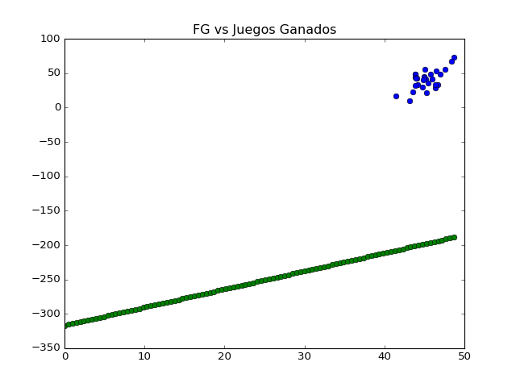

```python
imprime(X2, Y, myBeta2, 0)
```

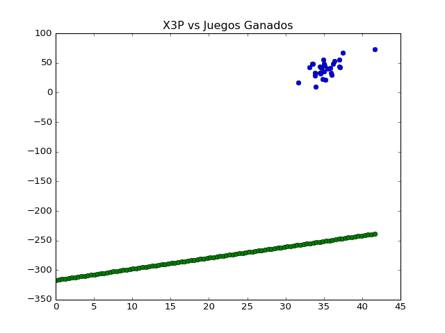

```python
imprime(X2, Y, myBeta2, 1)
```

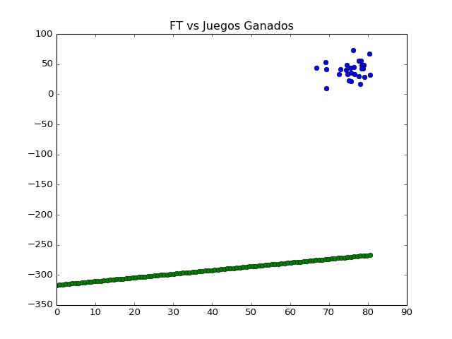

```python
imprime(X2, Y, myBeta2, 2)
```

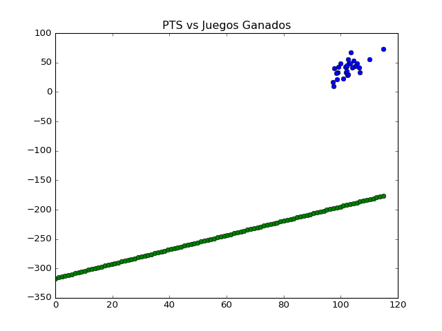

```python
imprime(X2, Y, myBeta2, 3)
```

### Cálculo del vector $\hat{y}$

Calculemos el vector $\hat{y}$ que es el vector aproximado por el método de mínimos cuadrados.

```python
Yaprox = np.dot(X2, myBeta2)
```

### Cálculo de la bondad de ajuste $R^2$

Calculemos ahora el coeficiente de determinación $R^2$ para poder estimar el error asociado a la aproximación lineal que calculamos.

```python
def bondad_ajuste(Y, Yaprox):
    Ymedia = np.mean(Y)
    'Calcula el coeficiente de determinación'
    SEC = 0
    STC = 0
    for yi in Y:
        STC += (np.float_(yi)-Ymedia)**2
    for yaproxi in Yaprox:
        SEC += (np.float_(yaproxi)-Ymedia)**2
    R2 = SEC/STC
    return R2
```

```python
R2 = bondad_ajuste(Y, Yaprox)
print(R2)
```

```
0.614824914886
```

```python
np.degrees(np.arccos(R2))
```

```
52.060800604684928
```

### Interpretación del $R^2$

[figure not shown]

## Regresión Lineal automática en R y Python

Si aplicamos la regresión lineal en **R**, obtenemos la siguiente información

[figure not shown]

Del mismo modo si lo hacemos en **Python**

```python
result = sm.ols(formula="W ~ FG + X3P + FT + PTS", data=nba_min).fit()
print (result.summary())
```

```
                            OLS Regression Results
==============================================================================
Dep. Variable:                      W   R-squared:                       0.615
Model:                            OLS   Adj. R-squared:                  0.548
Method:                 Least Squares   F-statistic:                     9.178
Date:                Sun, 17 Jul 2016   Prob (F-statistic):           0.000139
Time:                        08:04:43   Log-Likelihood:                -99.839
No. Observations:                  28   AIC:                             209.7
Df Residuals:                      23   BIC:                             216.3
Df Model:                           4
Covariance Type:            nonrobust
==============================================================================
                 coef    std err          t      P>|t|      [95.0% Conf. Int.]
------------------------------------------------------------------------------
Intercept   -316.6870     66.864     -4.736      0.000      -455.005  -178.369
FG             2.6321      1.469      1.792      0.086        -0.406     5.670
X3P            1.8721      1.368      1.369      0.184        -0.957     4.701
FT             0.6178      0.511      1.210      0.239        -0.439     1.674
PTS            1.2204      0.654      1.867      0.075        -0.132     2.573
==============================================================================
Omnibus:                        2.707   Durbin-Watson:                   1.660
Prob(Omnibus):                  0.258   Jarque-Bera (JB):                1.365
Skew:                          -0.156   Prob(JB):                        0.505
Kurtosis:                       1.964   Cond. No.                     5.24e+03
==============================================================================

Warnings:
[1] Standard Errors assume that the covariance matrix of the errors is correctly specified.
[2] The condition number is large, 5.24e+03. This might indicate that there are
strong multicollinearity or other numerical problems.
```

Podemos comprobar que los coeficientes encontrados así como el coeficiente $R^2$ coinciden. Además obtenemos información como el Error Residual Estándar así como la significancia de los coeficientes.

En este caso la sigma, es decir el error estándar es de 9.441

## Predicción

Utilizando los valores de las $\beta$ obtenidas, podemos tratar de predecir el valor de la variable dependiente a partir de las independientes.

```python
mav_FG = 44.4
mav_3P = 34.4
mav_FT = 79.4
mav_PTS = 102.3
cav_FG = 46.
cav_3P = 36.2
cav_FT = 74.8
cav_PTS = 104.3

JGanadosMav = np.float_(myBeta2[0])+np.float_(myBeta2[1])*mav_FG+np.float_(myBeta2[2])*mav_3P+np.float_(myBeta2[3])*mav_FT+np.float_(myBeta2[4])*mav_PTS
JGanadosCav = np.float_(myBeta2[0])+np.float_(myBeta2[1])*cav_FG+np.float_(myBeta2[2])*cav_3P+np.float_(myBeta2[3])*cav_FT+np.float_(myBeta2[4])*cav_PTS
print(JGanadosMav)
print(JGanadosCav)
```

```
38.4840059429
45.6641584587
```

## Repitiendo el experimento con una sola variable independiente

Para facilitar el análisis de máxima verosimilitud hagamos nuevamente la regresión considerando solamente una variable independiente (Porcentaje de tiros de campo). Con el propósito de ver la utilidad de la regresión lineal para predicción, eliminaremos un equipo de la tabla original antes de hacer la regresión, para posteriormente tratar de predecir cuantos juegos ganaría y contrastarlo contra el valor real.

```python
#nba-one_var contiene la matriz de datos con una sola variable independiente y sin el equipo "Dallas Mavericks"
nba_one_var = pd.read_csv('NBA-Stats-Una-Var.csv')
```

### Realizamos la regresión

```python
colsOneVar = ["FG%"]
XOneVar=nba_one_var.as_matrix(columns=colsOneVar)
YOneVar=np.matrix(nba_one_var.W.as_matrix(),float).T
```

```python
XOneVar2 = np.c_[np.ones(XOneVar.shape[0]), XOneVar]
```

```python
myBetaOneVar = betafinal(XOneVar2,YOneVar)
print (myBetaOneVar)
```

```
[[-220.16851121]
 [   5.77113765]]
```

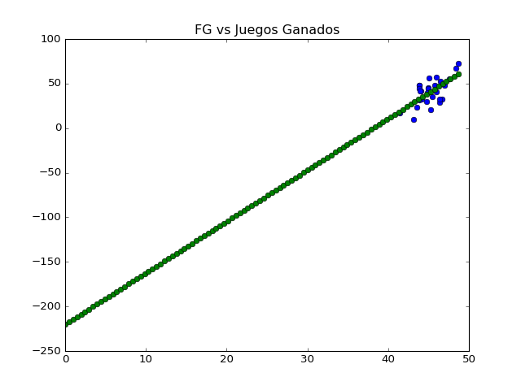

```python
imprime(XOneVar2, YOneVar, myBetaOneVar, 0)
```

```python
YOneVaraprox = np.dot(XOneVar2, myBetaOneVar)
```

```python
R2OneVar = bondad_ajuste(YOneVar, YOneVaraprox)
print(R2OneVar)
```

```
0.431881063615
```

### Predicción

```python
MavericksFG = 44.4
JGanados = np.float_(myBetaOneVar[0])+np.float_(myBetaOneVar[1])*MavericksFG
print(JGanados)
```

```
36.0700004758
```

Si analizamos la tabla original, el número de juegos ganados de los Mavericks de Dallas fue de **42**, como podemos apreciar en el análisis del R2, nuestro vector aproximado apenas representa el **43%** de la información original, lo cual explica la diferencia entre nuestra predicción (**36** juegos ganados) contra el valor observado en la realidad. De hecho, si lo comparamos con la predicción realizada con la regresión que incluía más variables, nos encontramos con que la primera predicción fue más certera **(38.48)** lo cual tiene sentido pues si recordamos, el $R^2$ nos decía que había una mejor representación del valor original.

## Conclusiones

Como pudimos observar, los datos meramente ofensivos como lo son el porcentaje de Tiros de Campo, de Tiros de 3 Puntos, de Tiros Libres y el total de puntos, no pueden predecir adecuadamente el número de partidos que un equipo ganará en una temporada regular. Esta situación es explicable, pues también deben tomarse en consideración otro tipo de variables, particularmente, las variables defensivas como lo pueden ser los robos de balón y los bloqueos.